# 20230306 R基本概念(一)

簡立宇

2023-02-22

- 學習資源

> https://www.w3cschool.cn/r/ https://r4ds.had.co.nz/index.html https://bookdown.org/ccolonescu/RPoE4/intro.html
- 解題資源

> https://stackoverflow.com/

## 一、資料型態

- integer(整數)
- number(實數)
- logic(布林)
- character(字串)
- factor(類別變數)
- vector(陣列)
- list(列表)
- matrix(矩陣)
- dataframe(資料框)

```r
Sam <- 178
May <- 170.5
Kate <- "QAQ"
str(Sam)
```

```
##  num 178
```

```r
str(May)
```

```
##  num 170
```

```r
str(Kate)
```

```
##  chr "QAQ"
```

```r
gender <- c("F", "M", "F", "M", "F")  # character vector

#list
Sam <- list(gender="M", Height = 178,NUM="123")
Sam
```

```
## $gender
## [1] "M"
##
## $Height
## [1] 178
##
## $NUM
## [1] "123"
```

```r
#matrix

a <- matrix(c(1:6), nrow=3, ncol=2)
a
```

```
##      [,1] [,2]
## [1,]    1    4
## [2,]    2    5
## [3,]    3    6
```

```r
b <- matrix(c("習","大","近","帥","平","哥"), nrow=2, ncol=3)
b
```

```
##      [,1] [,2] [,3]
## [1,] "習" "近" "平"
## [2,] "大" "帥" "哥"
```

```r
b[2,2]
```

```
## [1] "帥"
```

```r
#data frame
Student <- data.frame(Name = c("Sam","May"),#character vector
                      Height = c(178,170.5),#number vector
                      NUM = c("123","234"),
                      Male = c(TRUE,FALSE))
View(Student)


str(Student)
```

```
## 'data.frame':    2 obs. of  4 variables:
##  $ Name  : chr  "Sam" "May"
##  $ Height: num  178 170
##  $ NUM   : chr  "123" "234"
##  $ Male  : logi  TRUE FALSE
```

```r
str(Student$NUM)
```

```
##  chr [1:2] "123" "234"
```

```r
str(Student$Height)
```

```
##  num [1:2] 178 170
```

```r
Student$NUM[1]
```

```
## [1] "123"
```

```r
Student$Name[2]
```

```
## [1] "May"
```

```r
#強迫轉換資料型態
Kate <- as.integer(May)
str(Kate)
```

```
##  int 170
```

```r
gender <- factor(gender)   #轉換成factor型態
gender
```

```
## [1] F M F M F
## Levels: F M
```

### 小結

1. c()就是以陣列 (vector)形式儲放資料【很重要，常用!】
2. 加上”“就會把資料變成字串
3. dataframe型態中會集合很多種資料型態，之後會很常用到

### 練習

建立一個dataframe，可以呈現出以下資訊。

| 姓名 | 星座 | 年齡 | 是否上過戀愛家教 |
| --- | --- | --- | --- |
| 習近平 | NA | 69 | FALSE |
| 紀威 | 巨蟹座 | 24 | TRUE |
| 愛德華 | 天秤座 | 30 | FALSE |

## 二、套件介紹

```r
#install.packages("fortunes", repos="http://cran.us.r-project.org")
library(fortunes)
fortune()
```

```
##
## Statistical computing is not easy, so how could R be? Who has ever claimed it
## is? Any package that makes statistical computing appear to be easy is probably
## giving you wrong answers half the time, or is extremely limited in scope.
##    -- Duncan Murdoch (in a discussion about the usability of R)
##       R-help (May 2006)
```

```r
#install.packages("cowsay", repos="http://cran.us.r-project.org")
library(cowsay)
say("喵喵喵~")
```

```
##
##  --------------
## 喵喵喵~
##  --------------
##     \
##       \
##         \
##             |\___/|
##           ==) ^Y^ (==
##             \  ^  /
##              )=*=(
##             /     \
##             |     |
##            /| | | |\
##            \| | |_|/\
##       jgs  //_// ___/
##                \_)
##
```

```r
#來載入一些有用的套件之後會用到
#install.packages("tidyverse", repos="http://cran.us.r-project.org")
#library(tidyverse)
#install.packages("dplyr", repos="http://cran.us.r-project.org")
library(dplyr)
```

### 小結

1. 套件就是工具箱裡的工具，每次不用都帶在身上，有需要時再載入即可。
2. 載入套件後，功能會以函數function的形式來召喚。

### 補充:寫一個函數

```r
#現有R函數
mean(1:10)
```

```
## [1] 5.5
```

```r
#如果自己寫
myMean<-function(x){
    y<-sum(x)/length(x)
    return(y)
}
myMean(1:10)
```

```
## [1] 5.5
```

```r
#小心!!如果自己寫函數，不要取跟現有R函數一樣的名字。
```

## 三、寫入寫出檔案

```r
library(readr)
data <- read_csv("C:/Users/user/Desktop/2023_R與言教學/吳政隆.csv")
```

```
## ──────────────────────────────────────────────────────── Delimiter: "," chr
## (3): title, content, source dbl (1): ...1 date (1): Date
```

```r
View(data)

data$title[1] <- '汪汪'

write.csv(data, "亂改的.csv", row.names=FALSE)

library(dplyr)
Newdata <- select(data, c("title","Date"))
View(Newdata)
library("writexl")
write_xlsx(Newdata,"亂改的.xlsx")
#知道自己的檔案路徑
getwd()
```

```
## [1] "C:/Users/user/Desktop/2023_R與言教學"
```

### 練習

把「正部級資料練習用」檔案叫出來，Name第二列是誰?title第100列是什麼? 把title第一列改成「練習」，然後以csv格式輸出。 只保留Name與title，以xlsx格式輸出。

### 補充:從網路上找資源

```r
library(rio) #rio套件有import()可以讀取網路的連結資料
url = "https://raw.githubusercontent.com/owid/covid-19-data/master/public/data/vaccinations/country_data/China.csv"
tmp<-rio::import(url)
View(tmp)

#https://github.com/modood/Administrative-divisions-of-China

url2 <- "https://raw.githubusercontent.com/modood/Administrative-divisions-of-China/master/dist/areas.csv"
tmp2<-rio::import(url2)
View(tmp2)
```

### 補充:網友寫好的套件，下載後也能取得資料

```r
###使用失敗的rstatscn

#install.packages('rstatscn')
#library(rstatscn)
#查查看這個套件怎麼用 ??rstatscn
#statscnRegions(dbcode = "fsnd")

#出現Error:此憑證鏈結是由不受信任的授權單位發出的。
#上網查一下套件寫的方式，發現是提供使用者訪問http://data.stats.gov.cn的接口
#https://github.com/cran/rstatscn/blob/master/R/rstatscn.R
```

```r
###mapchina
#install.packages("mapchina")
library(mapchina)
head(china)
```

```
## Simple feature collection with 6 features and 13 fields
## Geometry type: MULTIPOLYGON
## Dimension:     XY
## Bounding box:  xmin: 115.4248 ymin: 39.44473 xmax: 116.8805 ymax: 41.05936
## Geodetic CRS:  WGS 84
## # A tibble: 6 × 14
##   Code_…¹ Code_…² Code_…³ Name_…⁴ Name_…⁵ Name_…⁶ Pinyin Pop_2…⁷ Pop_2…⁸ Pop_2…⁹
##   <chr>   <chr>   <chr>   <chr>   <chr>   <chr>   <chr>    <dbl>   <dbl>   <dbl>
## 1 110101  1101    11      北京市  <NA>    东城区  Dōngc…  881763  919253      NA
## 2 110102  1101    11      北京市  <NA>    西城区  Xīché… 1232823 1243315      NA
## 3 110114  1101    11      北京市  <NA>    昌平区  Chāng…  614821 1660501      NA
## 4 110115  1101    11      北京市  <NA>    大兴区  Dàxīn…  671444 1365112      NA
## 5 110111  1101    11      北京市  <NA>    房山区  Fángs…  814367  944832      NA
## 6 110116  1101    11      北京市  <NA>    怀柔区  Huáir…  296002  372887      NA
## # … with 4 more variables: Pop_2018 <dbl>, Area <dbl>, Density <dbl>,
## #   geometry <MULTIPOLYGON [°]>, and abbreviated variable names ¹Code_County,
## #   ²Code_Perfecture, ³Code_Province, ⁴Name_Province, ⁵Name_Perfecture,
## #   ⁶Name_County, ⁷Pop_2000, ⁸Pop_2010, ⁹Pop_2017
```

```r
#View(china)

#library(dplyr)
#tmpG <- china%>%group_by(Code_Province)
#tmpG
#tmpG <- china%>%group_by(Code_Province)%>%
#  summarise(mean_g = mean(Density), #按照省來分，地級的平均人口密度
#            sd_g = sd(Density),
#            max_g = max(Density),
#            min_g = min(Density))
#發現資料沒辦法分析，先觀察一下資料
str(china$geometry)
```

```
## sfc_MULTIPOLYGON of length 2901; first list element: List of 1
##  $ :List of 1
##   ..$ : num [1:21, 1:2] 116 116 116 116 116 ...
##  - attr(*, "class")= chr [1:3] "XY" "MULTIPOLYGON" "sfg"
```

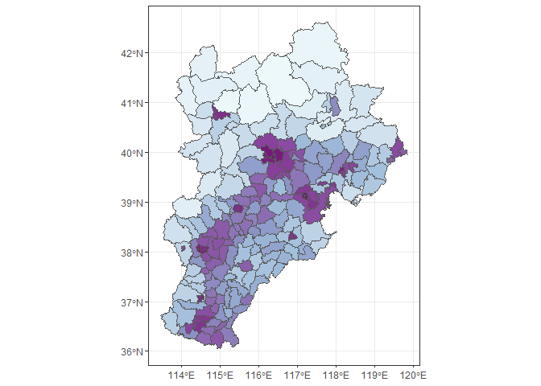

```r
data <- data.frame(Code_Province = china$Code_Province,Density = china$Density)
View(data)
tmpG <- data%>%group_by(Code_Province)%>%
  summarise(mean_g = mean(Density), #按照省來分，地級的平均人口密度
            sd_g = sd(Density),
            max_g = max(Density),
            min_g = min(Density))
View(tmpG)




#試試看範例文件https://github.com/xmc811/mapchina
library(ggplot2)
df <- china %>%
        filter(Code_Province %in% c("11","12","13")) #北京天津河北

ggplot(data = df) +
        geom_sf(aes(fill = rank(Density))) +
        scale_fill_distiller(palette = "BuPu", direction = 1) +
        theme_bw() +
        theme(legend.position = "none")
```

### 補充:偶爾可能會用到的R環境問題

```r
globalenv() #檢視目前環境
```

```
## <environment: R_GlobalEnv>
```

```r
ls(envir = globalenv(),100) #檢視有什摩變數
```

```
##  [1] "a"       "b"       "data"    "df"      "gender"  "Kate"    "May"
##  [8] "myMean"  "Newdata" "Sam"     "Student" "tmp"     "tmp2"    "tmpG"
## [15] "url"     "url2"
```

```r
#rm(list=ls())　#清空所有變數
#load("XXXX.Rdata") #把目前跑到的結果存起來，下次開電腦還在
```

## 回家作業

練習使用dplyr套件 > https://dplyr.tidyverse.org/

了解「%>%」用法，可以讓程式更精簡 > https://bookdown.org/tonykuoyj/eloquentr/data-workflow.html

1. 試著使用「正部級資料練習用」檔案，篩選出「李克強」的資料，輸出成csv檔交給我， hint:dplyr套件的filter功能
2. 請將上次工作的資料，修改完後，做成csv檔交給我。 dataframe的欄位須符合下面格式。如果內文都已經刪除了，則不用將資料建立進dataframe。

| num | Name | title | url | pubtime | Content |
| --- | --- | --- | --- | --- | --- |
| 12098 | 夏寶隆 | 丁薛祥、王晨、刘鹤、孙春兰、李希、李强、李鸿忠、杨洁篪…. | http://www.news.cn/mrdx/2022-10/18/c_1310670278.htm | 2022-10-18 09:06:16 | 习近平总书记作的报告是全面建设社会主义现代化国家、全面推进中华民族伟大复兴的总纲领、总指引、总动员，完全赞成、坚决拥护。一组组数据、一项项成就、一个个目标、一条条举措，令人更深刻感受到以习近平同志为核心的党中央英明领导、习近平新时代中国特色社会主义思想伟力，更深刻感受到中国特色社会主义制度好，更深刻感受到只有斗争才能赢得胜利。报告深刻总结“一国两制”实践特别是香港实现由乱到治历史性成就，系统阐述坚… |

#### 課堂練習答案

```r
data <- data.frame("姓名" = c("習近平","紀威","愛德華"),
                   "星座" = c(NA,"巨蟹座","天秤座"),
                   "年齡" = c(69,24,30),
                   "是否上過戀愛家教" = c(F,T,F))
head(data)
```

```
##     姓名   星座 年齡 是否上過戀愛家教
## 1 習近平   <NA>   69            FALSE
## 2   紀威 巨蟹座   24             TRUE
## 3 愛德華 天秤座   30            FALSE
```

```r
summary(data)
```

```
##      姓名               星座                年齡      是否上過戀愛家教
##  Length:3           Length:3           Min.   :24.0   Mode :logical
##  Class :character   Class :character   1st Qu.:27.0   FALSE:2
##  Mode  :character   Mode  :character   Median :30.0   TRUE :1
##                                        Mean   :41.0
##                                        3rd Qu.:49.5
##                                        Max.   :69.0
```

```r
row.names(data)
```

```
## [1] "1" "2" "3"
```

```r
rownames(data)
```

```
## [1] "1" "2" "3"
```

```r
names(data)
```

```
## [1] "姓名"             "星座"             "年齡"             "是否上過戀愛家教"
```

```r
names(data) <- c("Name", "Zodiac", "Age","Edward_OrNot")

View(data)

library(readr)
X <- read_csv("正部級資料練習用.csv")
```

```
## ──────────────────────────────────────────────────────── Delimiter: "," chr
## (5): Name, title, url, sitename, Content dbl (2): ...1, Unnamed: 0 dttm (1):
## pubtime
```

```r
View(X)
X$Name[2]
```

```
## [1] "李克強"
```

```r
X$title[100]
```

```
## [1] "（二十大受权发布）中国共产党第二十次全国代表大会在京开幕&nbsp;习近平代表第十九届中央委员会向大会作报告"
```

```r
NewX <- select(X, c("title","Name"))
```